Welcome to week 4!!!

Today, we will be working through some heteroskedasticity examples.

In order to do that though, we need two things: some data and our handy dandy pacman package. We’ll be using the `Caschool` data from `Ecdat` to look at some fun data.

# Lesson 0: loading data and packages

First, let’s load pacman. If you need to, run `install.packages("pacman")` first. If you run into errors, run `library(Ecdat,ggplot2)` to get around pacman install concerns. For everybody else,

```r
library(pacman)
#install.packages("Ecdat") if necessary
p_load(Ecdat, tidyverse, ggplot2, sandwich, lmtest)
#Let's explore our dataset, Caschool
```

The `Ecdat` contains the `Caschool` dataset which features all sorts of fun heterokedasticity we can look at.

Let’s do some exploration on our own. How do we inspect something? We can ask R using the `?` key

```r
?Caschool
```

We’re going to start with some exploration on our own.

Question1: Run this command on your own. How many observations are there? What is the timespan the data covers?

Let’s take a peak at the first few rows of the dataset. How do we do this?

```r
#Let's pass in our caschool data to a head command
head(Caschool)
```

```
##   distcod  county                        district grspan enrltot teachers
## 1   75119 Alameda              Sunol Glen Unified  KK-08     195    10.90
## 2   61499   Butte            Manzanita Elementary  KK-08     240    11.15
## 3   61549   Butte     Thermalito Union Elementary  KK-08    1550    82.90
## 4   61457   Butte Golden Feather Union Elementary  KK-08     243    14.00
## 5   61523   Butte        Palermo Union Elementary  KK-08    1335    71.50
## 6   62042  Fresno         Burrel Union Elementary  KK-08     137     6.40
##   calwpct mealpct computer testscr   compstu  expnstu      str    avginc
## 1  0.5102  2.0408       67  690.80 0.3435898 6384.911 17.88991 22.690001
## 2 15.4167 47.9167      101  661.20 0.4208333 5099.381 21.52466  9.824000
## 3 55.0323 76.3226      169  643.60 0.1090323 5501.955 18.69723  8.978000
## 4 36.4754 77.0492       85  647.70 0.3497942 7101.831 17.35714  8.978000
## 5 33.1086 78.4270      171  640.85 0.1280899 5235.988 18.67133  9.080333
## 6 12.3188 86.9565       25  605.55 0.1824818 5580.147 21.40625 10.415000
##       elpct readscr mathscr
## 1  0.000000   691.6   690.0
## 2  4.583333   660.5   661.9
## 3 30.000002   636.3   650.9
## 4  0.000000   651.9   643.5
## 5 13.857677   641.8   639.9
## 6 12.408759   605.7   605.4
```

Question 2: What is the range of school size? Question 3: What is the range of district average income ? Question 4: What is the range of student to teacher ratio? Question 5: What is the range of enrollment? Question 6: What variables do we have to use to measure student outcomes?

I think using some function of our test scores would work well.

Let’s try to figure out what the range of the total average score (reading + math) is? How should we do this?

We’ll use some tools from our friendly neighborhood tidyverse to solve this. Remember our mutate command? We’ll be using that.

```r
#We need the tidyverse, so if you haven't already, run the following:
#p_load(tidyverse)

#Generate total scores by adding reading and math scores together.
Caschool <- mutate(Caschool, scrtot = readscr + mathscr)
```

Now, we need to do some analysis. Back to regressions.

# Lesson 1: Running Regressions! Again!

Let’s run the linear regression of total score on income, student-to-teacher ratio, enrollment and expenditures per student. First, let’s explore a little.

```r
ols1 <- lm(data = Caschool, scrtot ~ avginc + str + enrltot + expnstu)
summary(ols1)
```

```
##
## Call:
## lm(formula = scrtot ~ avginc + str + enrltot + expnstu, data = Caschool)
##
## Residuals:
##     Min      1Q  Median      3Q     Max
## -80.657 -17.753   2.213  17.866  62.657
##
## Coefficients:
##               Estimate Std. Error t value Pr(>|t|)
## (Intercept)  1.313e+03  2.783e+01  47.171  < 2e-16 ***
## avginc       3.864e+00  1.851e-01  20.876  < 2e-16 ***
## str         -1.395e+00  8.927e-01  -1.563   0.1188
## enrltot     -1.611e-03  3.411e-04  -4.722  3.2e-06 ***
## expnstu     -6.052e-03  2.613e-03  -2.316   0.0211 *
## ---
## Signif. codes:  0 '***' 0.001 '**' 0.01 '*' 0.05 '.' 0.1 ' ' 1
##
## Residual standard error: 25.86 on 415 degrees of freedom
## Multiple R-squared:  0.5439, Adjusted R-squared:  0.5395
## F-statistic: 123.7 on 4 and 415 DF,  p-value: < 2.2e-16
```

On your own, interpret coefficients. In particular, think about the coefficient on expnstu: it’s significant at the 5% level. Why might we see a **negative** sign on expenditures per student?

Ok, now we need to find a way to examine heteroskedasticity. The first step in doing that is to recover errors, which we have to figure out. Let’s do that.

# Lesson 2: Retrieving Residuals from an LM model

Create the residuals of the regression you just ran. Hint: you can use the mutate command, combined with the `resid(your_lm_model)` command. This will return a vector of residuals! This is super handy, especially for this section. Let’s create a new column in our dataframe with our errors.

```r
Caschool <- mutate(Caschool, resid1 = resid(ols1))
```

However, we know this is the heteroskedasticity lab, so we need to check for heteroskedasticity. How would we do this?

Plot residuals against each of the four explanatory variables!

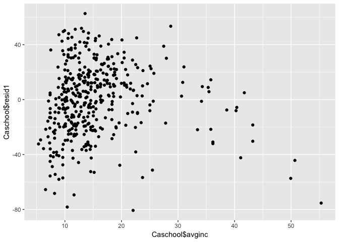

```r
#Let's use our qplot command to graph our X variables against our residuals to see if they seem reasonable. Think a bit about
#what 'reasonable' means.

#Average income
qplot(Caschool$avginc, Caschool$resid1)
```

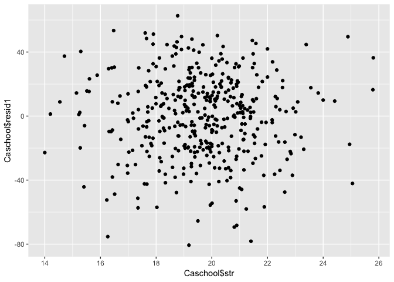

```r
#student teacher ratio
qplot(Caschool$str, Caschool$resid1)
```

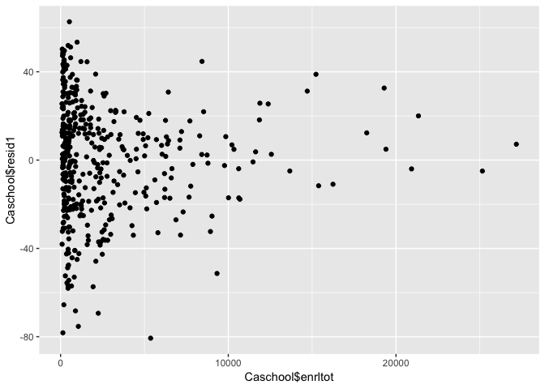

```r
#enrollment total
qplot(Caschool$enrltot, Caschool$resid1)
```

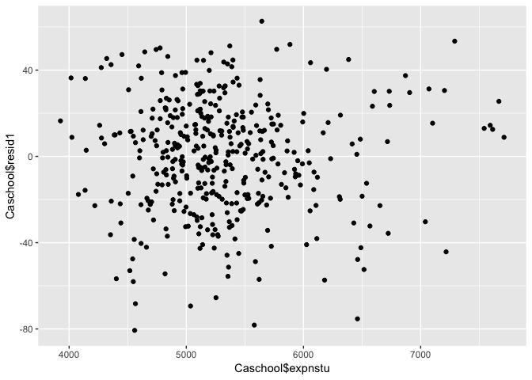

```r
#expenditures per student
qplot(Caschool$expnstu, Caschool$resid1)
```

Does it appear as though our disturbances are heteroskedastic? explain.

Why do we care about heteroskedasticity? What issues does that cause with our assumptions about OLS?

Let’s Run a similar regression but this time let’s use some common transformation techiniques. Why do we want to do this?

The reason why we want to first try model specifications is because model mispecification itself can cause heteroskedascity. Why do log-type heteroskedasticities help us sometimes?

Let’s start with a log-linear specification. How would we go about this?

```r
#Let's run a regression with  the form log(y) = x1 + x2 + ...
lm_i <- lm(data = Caschool, log(scrtot) ~ avginc + str + enrltot + expnstu)
```

Now, we can use our quick-plot tool to examine our new residuals

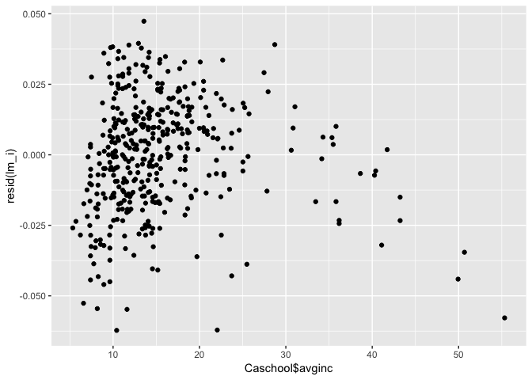

```r
qplot(Caschool$avginc, resid(lm_i))
```

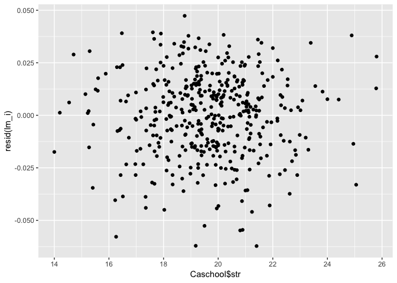

```r
qplot(Caschool$str, resid(lm_i))
```

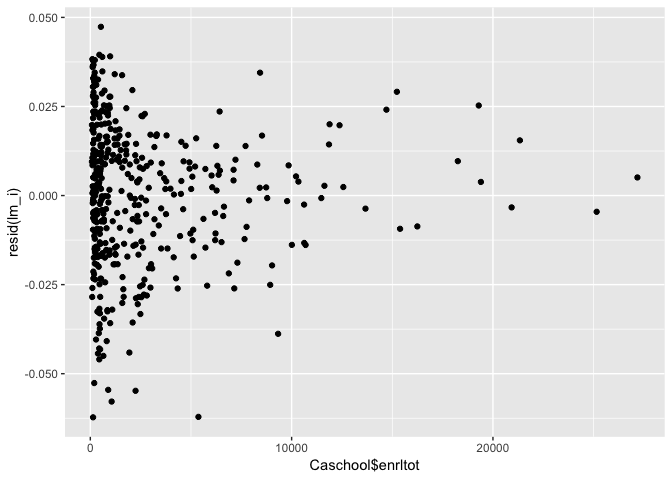

```r
qplot(Caschool$enrltot, resid(lm_i))
```

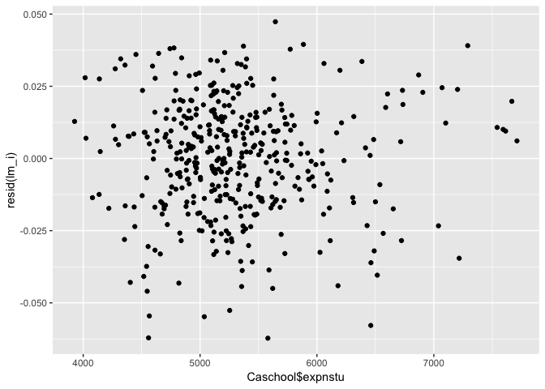

```r
qplot(Caschool$expnstu, resid(lm_i))
```

Next, let’s do a log-log specification

```r
#our form is now log(Y) = log(X1) + log(X2)...
lm_ii <- lm(data = Caschool, log(scrtot) ~ log(avginc) + log(str) + log(enrltot) + log(expnstu))
```

qplot again

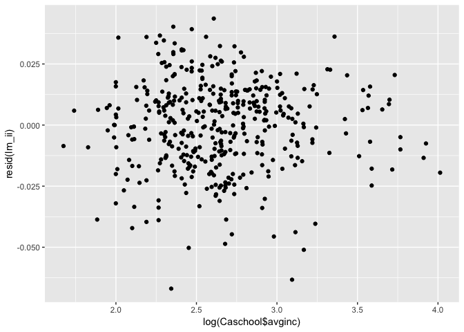

```r
qplot(log(Caschool$avginc), resid(lm_ii))
```

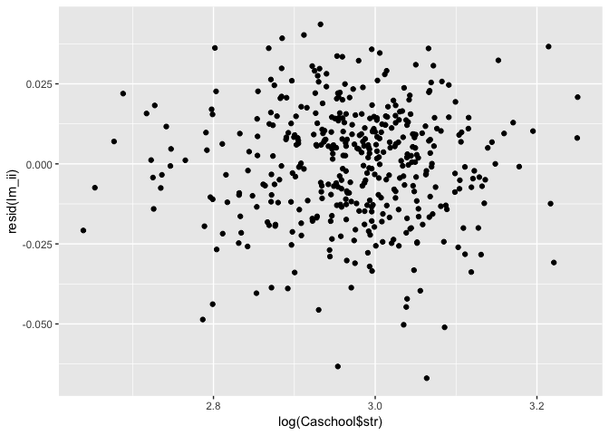

```r
qplot(log(Caschool$str), resid(lm_ii))
```

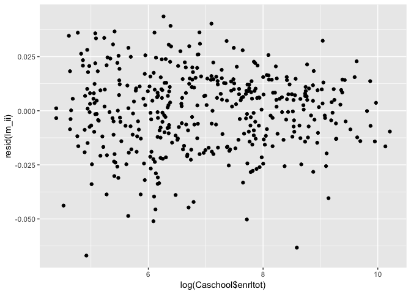

```r
qplot(log(Caschool$enrltot), resid(lm_ii))
```

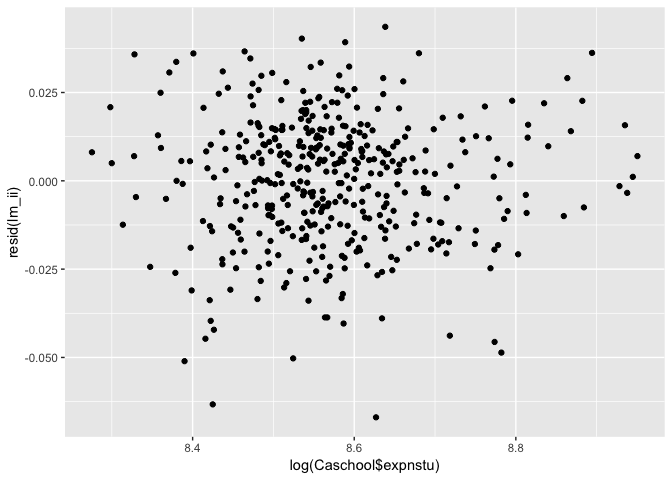

```r
qplot(log(Caschool$expnstu), resid(lm_ii))
```

```r
lm_checker <- lm(data = Caschool, (resid(lm_ii)^2) ~ log(avginc) + log(str) + log(enrltot))
summary(lm_checker)$r.squared
```

```
## [1] 0.0350631
```

That’s a bit hard to interpret. We might be okay here. But let’s keep looking. (Note: how would you interpret these coefficients?)

*How about lin-log?*

```r
#y = log(x1)+ log(x2)...
lm_iii <- lm(data = Caschool, scrtot ~ log(avginc) + log(str) + log(enrltot))
```

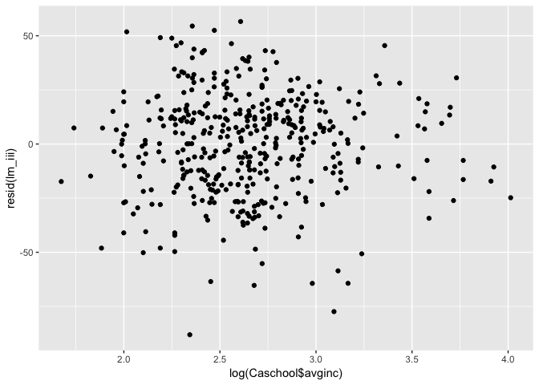

```r
qplot(log(Caschool$avginc), resid(lm_iii))
```

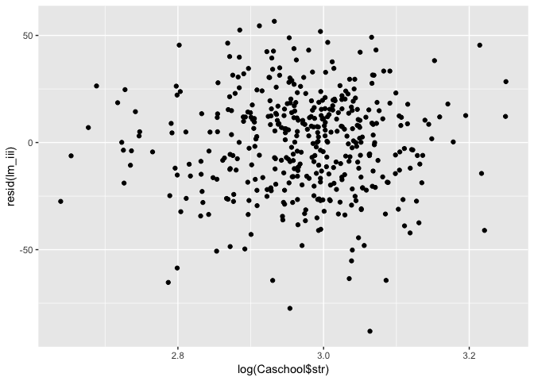

```r
qplot(log(Caschool$str), resid(lm_iii))
```

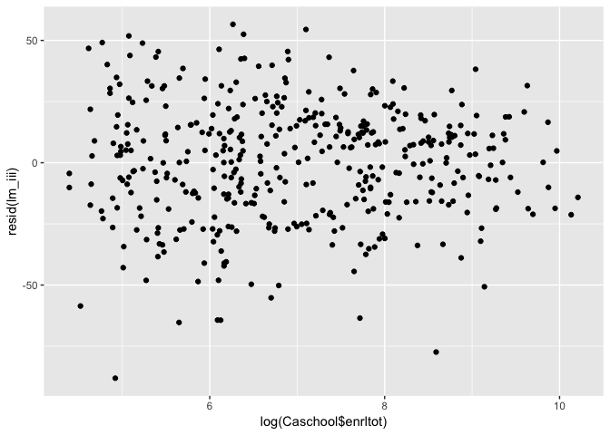

```r
qplot(log(Caschool$enrltot), resid(lm_iii))
```

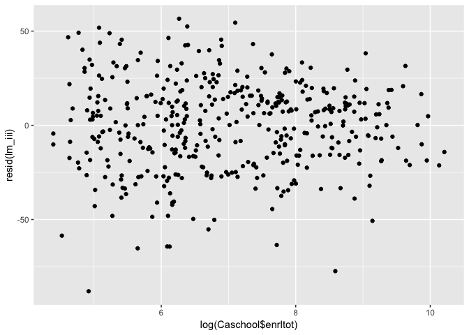

```r
qplot(log(Caschool$enrltot), resid(lm_iii))
```

Maybe interaction terms will help us…

```r
lm_iv <- lm(data = Caschool, scrtot ~ avginc + str + enrltot + expnstu + avginc:str + avginc:enrltot + avginc:expnstu + str:enrltot + str:expnstu + enrltot:expnstu)
```

Ok, let’s look at our errors

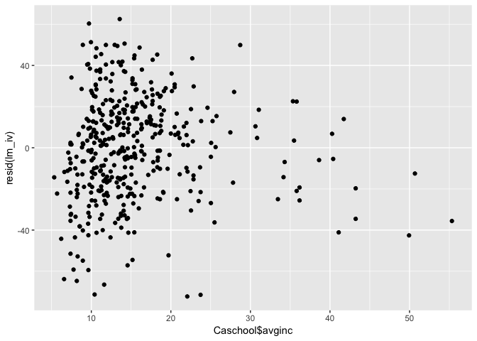

```r
qplot(Caschool$avginc, resid(lm_iv))
```

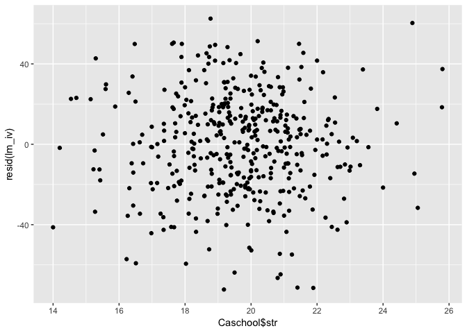

```r
qplot(Caschool$str, resid(lm_iv))
```

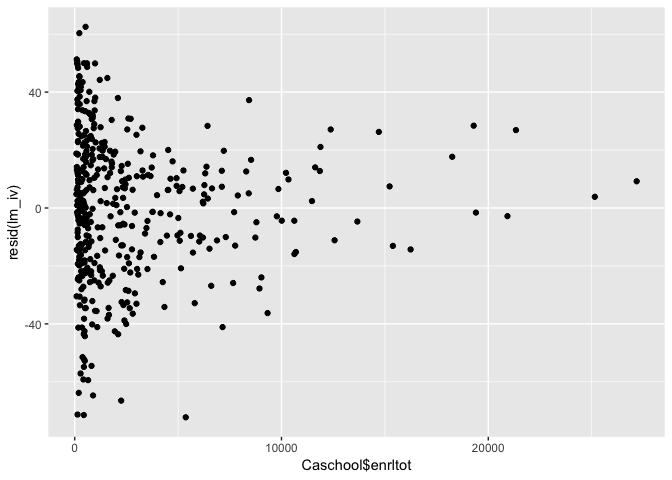

```r
qplot(Caschool$enrltot, resid(lm_iv))
```

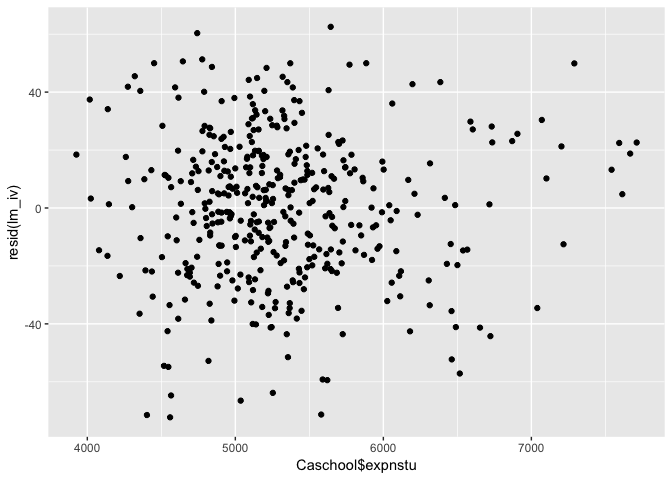

```r
qplot(Caschool$expnstu, resid(lm_iv))
```

```r
lm_v <- lm(data = Caschool, scrtot ~ avginc + str + enrltot + expnstu + avginc:str + avginc:enrltot + avginc:expnstu + str:enrltot + str:expnstu + enrltot:expnstu + avginc ^ 2 + str ^ 2 + enrltot ^ 2 + expnstu^2)
```

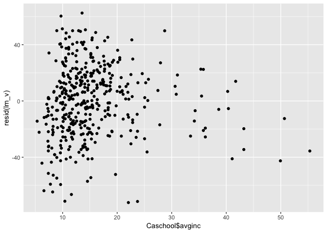

```r
qplot(Caschool$avginc, resid(lm_v))
```

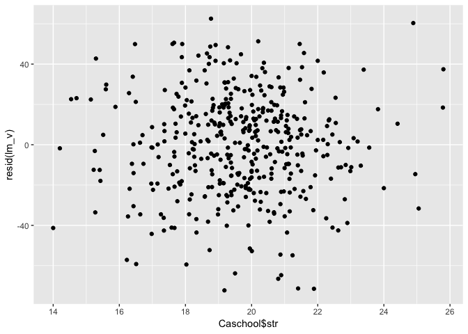

```r
qplot(Caschool$str, resid(lm_v))
```

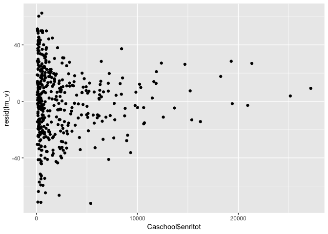

```r
qplot(Caschool$enrltot, resid(lm_v))
```

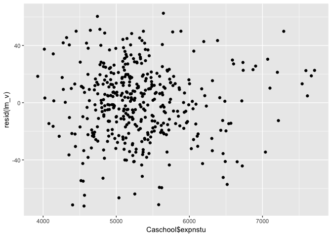

```r
qplot(Caschool$expnstu, resid(lm_v))
```

Shoot. Okay, what can we do from here on out? We need tests. Tests with funny names….